# Time Series Analysis

Incoming Examinations at Fargo Health Center

Vafa Saboori, PhD

## Introduction

This report analyzes the number of incoming examinations at Fargo Health Center in Abbeville, LA from January 2006 to December 2013. We will visualize the data and then apply three different time series models to determine which model provides the best fit.

## Data

The data consists of monthly counts of incoming examinations. We will import the data from a CSV file named `BAB268-XLS-ENG (Clean).csv`.

```r
# Load necessary libraries
library(forecast)
library(tseries)
library(readr)
```

```r
# Import the data
data <- read_csv("BAB268-XLS-ENG (Clean).csv")
# Convert the Date column to Date type
data$Date <- as.Date(data$Date, format = "%m/%d/%y")

# Display the first few rows of the data
head(data)
```

```
## # A tibble: 6 × 2
##   Date       IncomingExaminations
##   <date>                    <dbl>
## 1 2006-01-01                  362
## 2 2006-02-01                  436
## 3 2006-03-01                  926
## 4 2006-04-01                  490
## 5 2006-05-01                  508
## 6 2006-06-01                  901
```

## Visualization

We will visualize the incoming examinations over time.

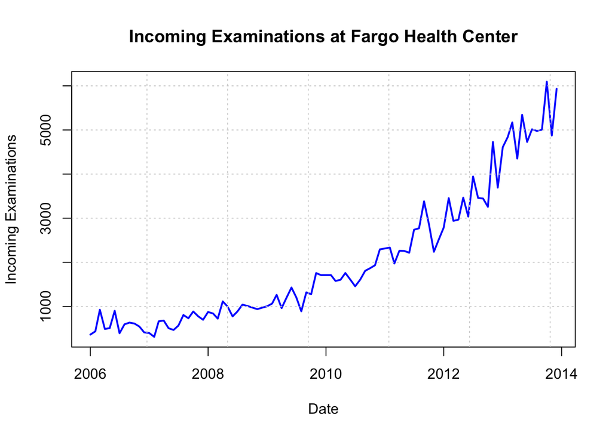

```r
# Plot the data using base R
plot(data$Date, data$IncomingExaminations, type = "l", # line
     main = "Incoming Examinations at Fargo Health Center",
     xlab = "Date", ylab = "Incoming Examinations",
     col = "blue", lwd = 2)

# Add grid lines
grid()
```

## Time Series Models

### Model 1: ARIMA

ARIMA (AutoRegressive Integrated Moving Average) is a popular time series forecasting model.

```r
# Fit ARIMA model
ts_data <- ts(data$IncomingExaminations, start = c(2006, 1), frequency = 12)
fit_arima <- auto.arima(ts_data)

# Forecast using ARIMA
forecast_arima <- forecast(fit_arima, h = 12)

# Display the forecasted values
forecast_arima
```

```
##          Point Forecast    Lo 80    Hi 80    Lo 95    Hi 95
## Jan 2014       5500.019 5079.858 5920.180 4857.439 6142.600
## Feb 2014       5700.633 5270.151 6131.116 5042.267 6358.999
## Mar 2014       5710.432 5239.066 6181.799 4989.539 6431.325
## Apr 2014       5777.697 5279.136 6276.258 5015.214 6540.181
## May 2014       5827.656 5300.479 6354.833 5021.408 6633.904
## Jun 2014       5882.827 5329.333 6436.321 5036.331 6729.323
## Jul 2014       5936.427 5357.576 6515.279 5051.151 6821.704
## Aug 2014       5990.501 5387.426 6593.576 5068.177 6912.825
## Sep 2014       6044.432 5418.050 6670.815 5086.463 7002.402
## Oct 2014       6098.407 5449.559 6747.254 5106.080 7090.733
## Nov 2014       6152.368 5481.806 6822.930 5126.832 7177.904
## Dec 2014       6206.333 5514.739 6897.928 5148.630 7264.036
```

# Plot ARIMA fit

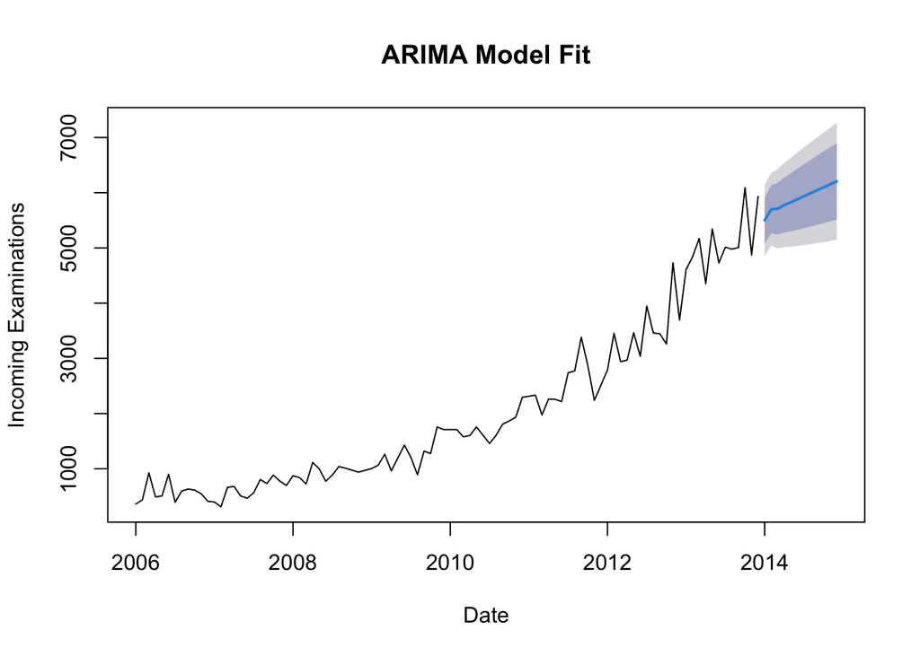

```r
plot(forecast_arima,
     main = "ARIMA Model Fit",
     xlab = "Date",
     ylab = "Incoming Examinations")
```

### Model 2: Exponential Smoothing (ETS)

ETS (Error, Trend, Seasonal) is another common approach for forecasting time series data.

```r
# Fit ETS model
fit_ets <- ets(ts_data)

# Forecast using ETS
forecast_ets <- forecast(fit_ets, h = 12)

# Display the forecasted values
forecast_ets
```

```
##          Point Forecast    Lo 80    Hi 80    Lo 95     Hi 95
## Jan 2014       5643.434 4202.962 7083.907 3440.422  7846.447
## Feb 2014       5743.770 4247.327 7240.214 3455.158  8032.383
## Mar 2014       5844.106 4289.416 7398.796 3466.413  8221.799
## Apr 2014       5944.442 4329.229 7559.656 3474.187  8414.698
## May 2014       6044.778 4366.766 7722.790 3478.480  8611.076
## Jun 2014       6145.114 4402.031 7888.197 3479.299  8810.929
## Jul 2014       6245.450 4435.029 8055.871 3476.650  9014.250
## Aug 2014       6345.786 4465.765 8225.807 3470.542  9221.030
## Sep 2014       6446.122 4494.244 8397.999 3460.983  9431.261
## Oct 2014       6546.458 4520.474 8572.441 3447.983  9644.932
## Nov 2014       6646.794 4544.460 8749.127 3431.551  9862.036
## Dec 2014       6747.130 4566.208 8928.051 3411.697 10082.562
```

# Plot ETS fit

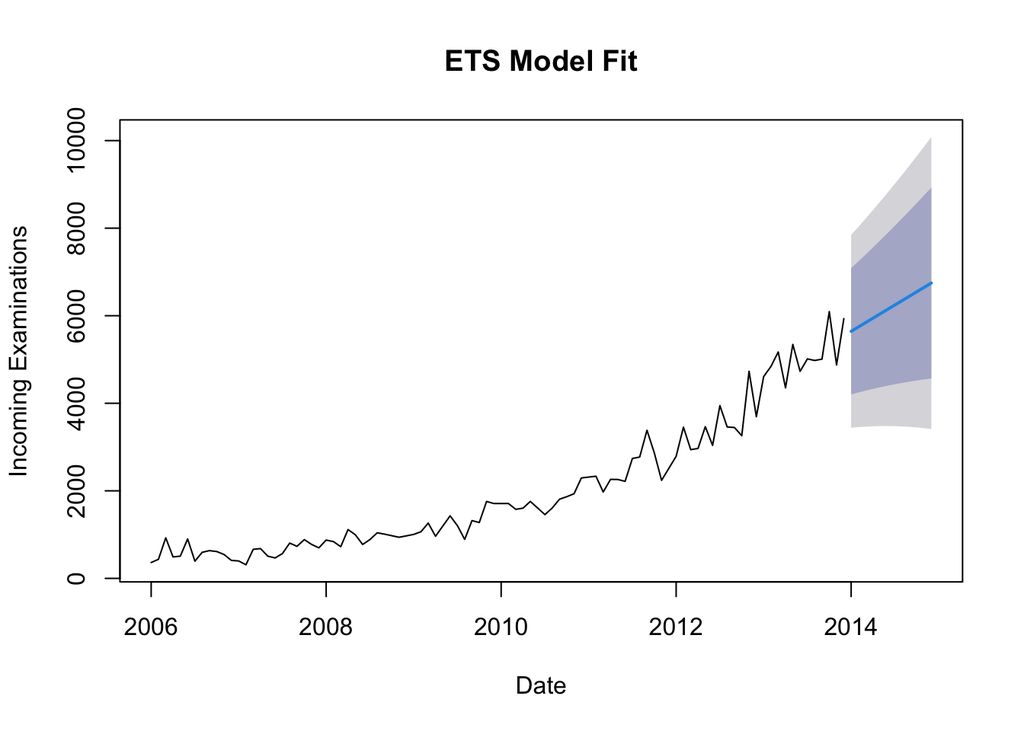

```r
plot(forecast_ets,
     main = "ETS Model Fit",
     xlab = "Date",
     ylab = "Incoming Examinations")
```

### Model 3: Seasonal Decomposition of Time Series (STL)

STL (Seasonal and Trend decomposition) is a method for decomposing time series data into seasonal, trend, and remainder components.

```r
# Fit STL model
fit_stl <- stl(ts_data,
               s.window = "periodic") # seasonal component estimated as periodic function.

# Forecast using STL
forecast_stl <- forecast(fit_stl, h = 12)

# Display the forecasted values
forecast_stl
```

```
##          Point Forecast    Lo 80    Hi 80    Lo 95    Hi 95
## Jan 2014       5890.793 5495.405 6286.180 5286.100 6495.486
## Feb 2014       6117.914 5722.128 6513.700 5512.612 6723.216
## Mar 2014       6259.785 5863.104 6656.466 5653.113 6866.457
## Apr 2014       6277.519 5879.251 6675.787 5668.420 6886.617
## May 2014       6596.564 6195.829 6997.299 5983.693 7209.435
## Jun 2014       6606.477 6202.217 7010.738 5988.215 7224.740
## Jul 2014       6855.828 6446.818 7264.839 6230.301 7481.355
## Aug 2014       6962.151 6547.019 7377.283 6327.261 7597.041
## Sep 2014       7224.724 6801.971 7647.477 6578.179 7871.269
## Oct 2014       7390.691 6958.714 7822.668 6730.040 8051.342
## Nov 2014       7489.284 7046.404 7932.164 6811.957 8166.611
## Dec 2014       7642.469 7186.952 8097.985 6945.817 8339.121
```

# Plot STL fit

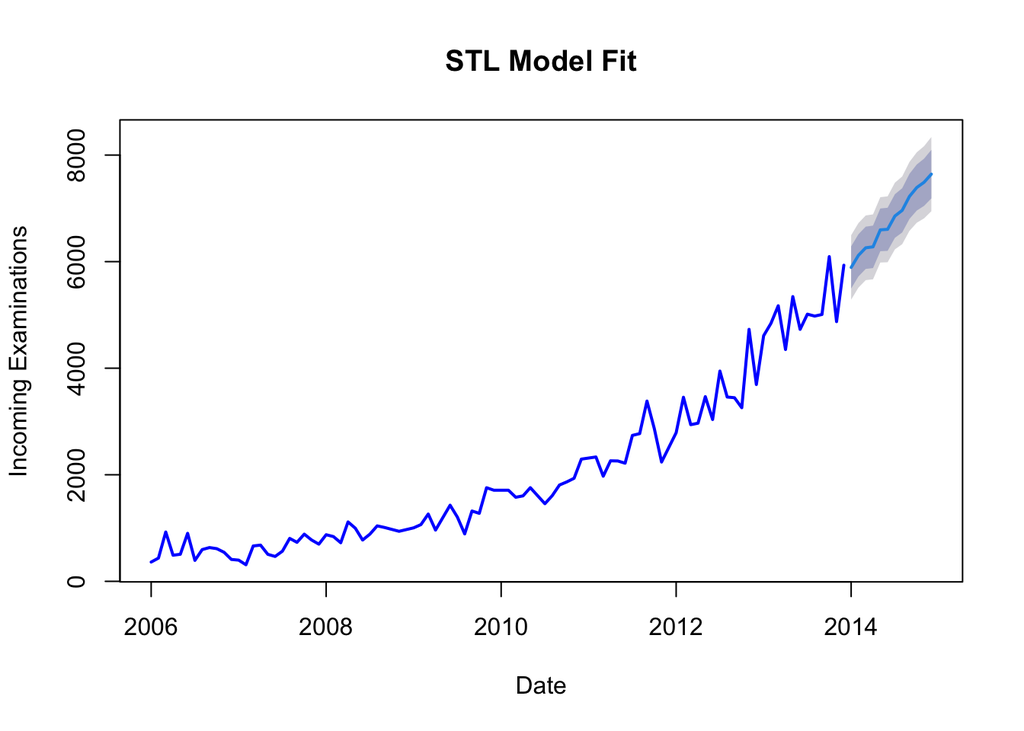

```r
plot(forecast_stl,
     main = "STL Model Fit",
     xlab = "Date",
     ylab = "Incoming Examinations",
     col = "blue", lwd = 2)
```

## Model Comparison

We will compare the three models based on their accuracy metrics: Mean Absolute Error (MAE), Root Mean Squared Error (RMSE), and Mean Absolute Percentage Error (MAPE).

```r
# Calculate accuracy metrics for each model
accuracy_arima <- accuracy(forecast_arima)
accuracy_ets <- accuracy(forecast_ets)
accuracy_stl <- accuracy(forecast_stl)

accuracy_arima
```

```
##                    ME     RMSE      MAE       MPE     MAPE      MASE       ACF1
## Training set 1.204923 320.9504 232.0202 -7.408409 16.74542 0.3456539 0.00146599
```

```r
accuracy_ets
```

```
##                    ME     RMSE      MAE       MPE     MAPE      MASE
## Training set 84.06321 324.9158 227.2836 -1.445822 15.26954 0.3385975
##                     ACF1
## Training set -0.06103407
```

```r
accuracy_stl
```

```
##                   ME     RMSE      MAE     MPE     MAPE     MASE       ACF1
## Training set 75.8628 302.0265 218.9557 1.20808 14.49633 0.326191 0.01889269
```

## Conclusion

Based on the accuracy metrics, we can determine which model provides the best fit for the data. The model with the lowest MAE, RMSE, and MAPE values is considered the best.

From the results, it appears that the STL (Seasonal and Trend decomposition) model is the best fit for forecasting incoming examinations at Fargo Health Center.

[output not shown]